# HW 4

```r
knitr::opts_chunk$set(echo = TRUE)
library("dplyr")
```

```r
library("datasets")
library("ggplot2")
data("ChickWeight", package="datasets")
df = ChickWeight
```

1. Get a frequency breakdown of the number of chicks, their average weight and the standard deviation of the weights in each of the diets at the start of the study. Store the resulting data frame in a variable named `weight0` and print.

```r
weight0 = df %>%
  group_by(Diet) %>% ## Group the df by diet
  summarize(Avg_Weight = mean(weight, na.rm=TRUE), Std_Dev_Weight = sd(weight, na.rm=TRUE), Number_Chicks = length(unique(Chick)))
  ## Using each diet group, create an average weight, standard deviation and num chicks in each diet group.

print(weight0)
```

```
## # A tibble: 4 x 4
##   Diet  Avg_Weight Std_Dev_Weight Number_Chicks
##   <fct>      <dbl>          <dbl>         <int>
## 1 1           103.           56.7            20
## 2 2           123.           71.6            10
## 3 3           143.           86.5            10
## 4 4           135.           68.8            10
```

2. Each chick should have twelve weight measurements. Use the `dplyr` package to identify how many measurements are there for each chick. Extract a subset of the data for all chicks with complete information, name the data set `complete`, and print the first 3 rows. (Hint: you might want to use mutate to introduce a helper variable consisting of the number of observations)

```r
complete = df %>%
  count(Chick) %>%
  filter( n == 12)

 print(complete[1:3,])
```

```
## # A tibble: 3 x 2
##   Chick     n
##   <ord> <int>
## 1 13       12
## 2 9        12
## 3 20       12
```

4. In the complete data set introduce a new variable that measures the current weight difference compared to day 0. Name this variable `weightgain` and print the first 3 rows of the new data frame.

```r
weightgain = df %>%
  group_by(Chick) %>%
  mutate(weight_gain = weight - weight[Chick == Chick & Time == 0])

print(weightgain[1:3,])
```

```
## # A tibble: 3 x 5
## # Groups:   Chick [1]
##   weight  Time Chick Diet  weight_gain
##    <dbl> <dbl> <ord> <fct>       <dbl>
## 1     42     0 1     1               0
## 2     51     2 1     1               9
## 3     59     4 1     1              17
```

5. Use `{ggplot2}` to create side-by-side boxplots of `weightgain` by `Diet` for day 21. Change the order of the categories in the Diet variable such that the boxplots are ordered by median `weightgain`, and the lower limit of the y axis should be 0. Describe the relationship in 2-3 sentences.

### As we go from diet 1 to diet 4 we see that the median of the weight gain is increased. The median of the weight gain has a small increase from diet 3 to diet 4. It is also important to notice that diet 3 produced the most fluctuation in weight gain, as the 1st and 3rd quartiles are the furthest spread from the median.

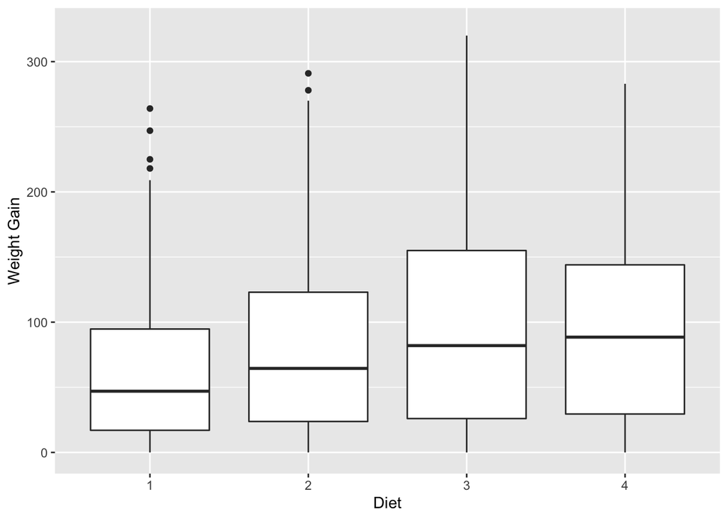

```r
ggplot(weightgain, aes(x=reorder(Diet, weight_gain, median), y = weight_gain)) + geom_boxplot() + xlab("Diet") + ylab("Weight Gain") + ylim(c(0,325))
```

6. Answer each of the following questions using numerical and graphical summary. Also explain what you found: (a) Which chick gained the most weight and which gained the least weight? (b) What diets were they on?

### From our graphical and numerical summaries we found that Chick 35 on diet 3 had the largest weight gain of 332. Using the same information we found that the chick with the least weight gain was Chick 24 on diet 2 with a weight gain of 32.

```r
# find max weight gain for each.
overall_gain <- weightgain %>%
  group_by(Chick) %>%
  filter(Time == max(weightgain$Time)) %>%
  arrange(weight_gain)
print(overall_gain[45,]) # Most
```

```
## # A tibble: 1 x 5
## # Groups:   Chick [1]
##   weight  Time Chick Diet  weight_gain
##    <dbl> <dbl> <ord> <fct>       <dbl>
## 1    373    21 35    3             332
```

```r
print(overall_gain[1,]) # Least
```

```
## # A tibble: 1 x 5
## # Groups:   Chick [1]
##   weight  Time Chick Diet  weight_gain
##    <dbl> <dbl> <ord> <fct>       <dbl>
## 1     74    21 24    2              32
```

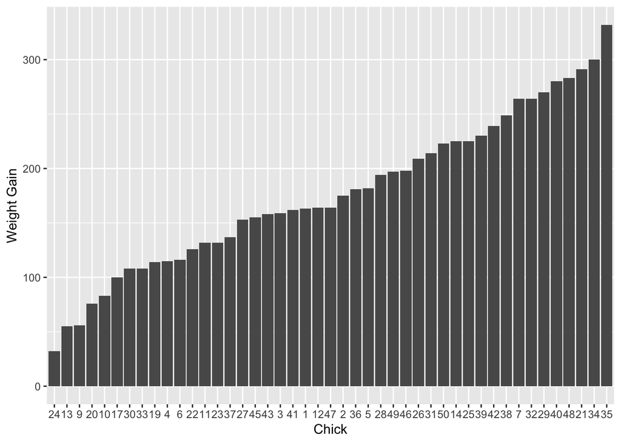

```r
ggplot(overall_gain, aes(x = reorder(Chick, weight_gain, abs), y = weight_gain)) + geom_col() + labs(x = "Chick", y = "Weight Gain")
```

7. For the chicks with the least and the most weight at time 0, plot their growth trajectories over time.

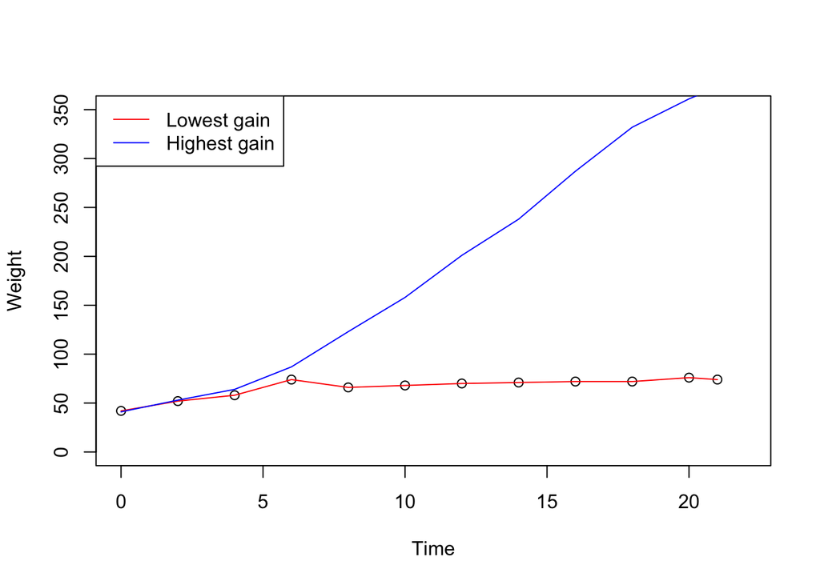

```r
total_gain <- weightgain %>%
  group_by(Chick) %>%
  filter(Time == max(weightgain$Time)) %>%
  arrange(weight_gain)

# get data for largest and smallest chick weights with time.
smallest = total_gain$Chick[1]
smallest_gain = df %>%
  filter(Chick == smallest)
time = smallest_gain$Time
lowest_weights = smallest_gain$weight

highest = total_gain$Chick[dim(total_gain)[1]]
highest_gain = df %>%
  filter(Chick == highest)
highest_weights = highest_gain$weight

v = rep(0, length(time))
for(i in seq_len(length(time))) {
  v[i] = mean(weightgain$weight[weightgain$Time == time[i]])
}
# Plot of highest and lowest weights.
plot(x = time, y = lowest_weights, xlab="Time", ylab="Weight", xlim=c(0, 22), ylim=c(0, 350))
lines(x = time, y = lowest_weights, col="red", lty=1)
lines(x = time, y = highest_weights, col="blue", lty=1)
legend("topleft", legend=c("Lowest gain", "Highest gain"), col=c("red", "blue"), lty=c(1,1))
```

8. Add to the previous plot the average growth trajectory for all chicks (calculated as the mean weight for each chick at each time). How do the trajectories compare?

### As we expected the average trajectory is in between the highest and lowest trajectories.

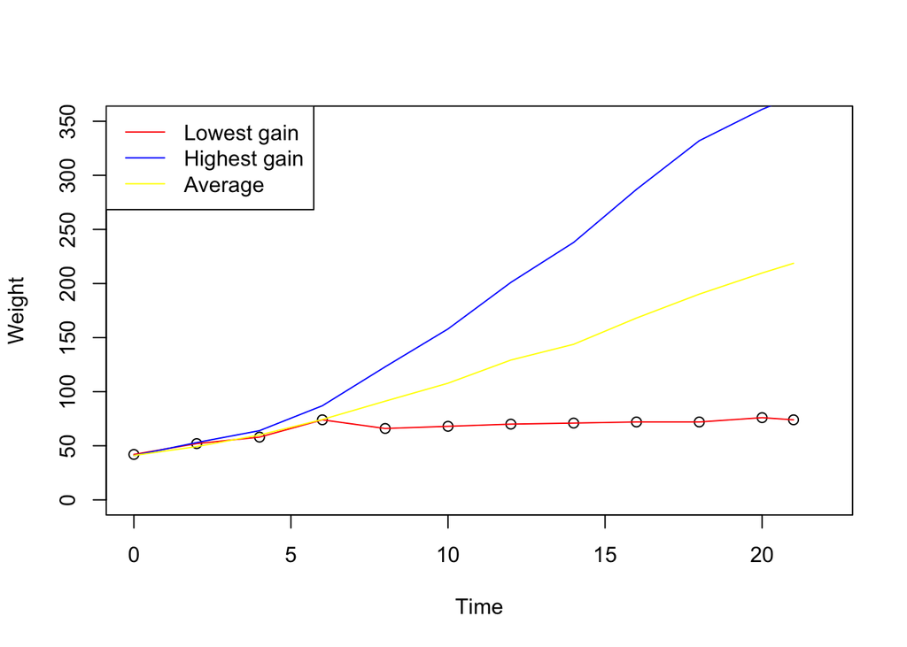

```r
# creates data set of average of all weight with respect to time.
j = rep(0, length(time))
for(i in seq_len(length(time))) {
  j[i] = mean(weightgain$weight[weightgain$Time == time[i]])
}

# Previous plot with average data
plot(x = time, y = lowest_weights, xlab="Time", ylab="Weight", xlim=c(0, 22), ylim=c(0, 350))
lines(x = time, y = lowest_weights, col="red", lty=1)
lines(x = time, y = highest_weights, col="blue", lty=1)
lines(x = time, y = j, col="yellow", lty=1)
legend("topleft", legend=c("Lowest gain", "Highest gain", "Average"), col=c("red", "blue", "yellow"), lty=c(1,1,1))
```

9. What else do you find interesting in the dataset? Show your exploratory analysis.

### When comparing the mean weight and median weight as a function of diet. We see that the trend for all diets is that the mean is larger than the median. This Proves our boxplot in which the 50% to 75% quartile is much larger than the 25% to 50% quartile. This means that the distribution and range of the weights above the median weight value are larger.

```r
avg_chick_weight = df %>%
  group_by(Chick) %>%
  mutate(avg_weight = mean(weight)) %>%
  group_by(Diet) %>%
  mutate(avg_weight_byDiet = mean(avg_weight)) %>%
  mutate(median_weight = median(weight))
head(avg_chick_weight[1,]) ## this is a sample data
```

```
## # A tibble: 1 x 7
## # Groups:   Diet [1]
##   weight  Time Chick Diet  avg_weight avg_weight_byDiet median_weight
##    <dbl> <dbl> <ord> <fct>      <dbl>             <dbl>         <dbl>
## 1     42     0 1     1           112.              103.            88
```

```r
# avg_chick_weight browse through average chick weight by diet and median weight. View trend and interpret.
```

Note: your submission is supposed to be fully reproducible, i.e. the TA and I will ‘knit’ your submission in RStudio. ### Song